# Binary effects of sediment on bleaching of adult corals

Lillian J. Tuttle

9/24/2020

#### Here I will explore how DEPOSITED AND SUSPENDED sediment affects the BLEACHING of tropical, scleractinean coral ADULTS. The database to be used is comprised of data extracted from studies deemed relevant during the systematic literature review process.

# The Dataset

## Deposited Sediment

Specifically, we will explore the results of 523 datapoints from 21 studies conducted in 3 oceans on 52 species within 32 genera (shown below only the top 10 species and genera, by number of datapoints).

```
##     n
## 1 523
```

```
##     Ref   n
## 1  DS71 112
## 2  DS04  70
## 3  DS46  44
## 4  DS29  40
## 5  DS27  39
## 6  DS30  36
## 7  DS35  26
## 8  DS17  24
## 9  DS45  24
## 10 DS16  19
## 11 DS32  16
## 12 DS07  13
## 13 DS03  12
## 14 DS43  12
## 15 DS05  10
## 16 DS33   8
## 17 DS26   6
## 18 DS21   4
## 19 DS40   4
## 20 DS23   2
## 21 DS42   2
```

```
##                                       Ref_name   n
## 1  HDR EOC and CSA Ocean Services, Inc. (2014) 112
## 2                      Duckworth et al. (2017)  70
## 3                        Stafford-Smith (1993)  44
## 4          Stafford-Smith (1990) PhD Chapter 4  40
## 5                 Sofonia (2006) PhD Chapter 4  39
## 6                       Stafford-Smith (1992)   36
## 7                      Wesseling et al. (1999)  26
## 8                                Piniak (2007)  24
## 9                                Rogers (1983)  24
## 10                Philipp and Fabricius (2003)  19
## 11                       Stewart et al. (2006)  16
## 12                             Hodgson (1990b)  13
## 13              Bessell-Browne et al. (2017a)   12
## 14                   Peters and Pilson (1985)   12
## 15                                Hodel (2007)  10
## 16                  Vargas-Angel et al. (2006)   8
## 17                Sofonia (2006) PhD Chapter 3   6
## 18            Abdel-Salam (1989) PhD Chapter 3   4
## 19                              Rogers (1979)    4
## 20                         Gowan et al. (2014)   2
## 21                                Selim (2007)   2
```

```
##      Ocean   n
## 1  Pacific 459
## 2 Atlantic  62
## 3   Indian   2
```

```
##                      Gsp  n
## 1   Porites_lobata/lutea 77
## 2     Porites_cylindrica 43
## 3       Leptoria_phrygia 42
## 4          Pavona_cactus 28
## 5          Porites_lutea 28
## 6            Porites_rus 28
## 7  Turbinaria_reniformis 24
## 8   Acropora_cervicornis 21
## 9  Montipora_capricornis 20
## 10 Montipora_tuberculosa 16
```

```
##    Updated_Genus   n
## 1        Porites 176
## 2      Montipora  65
## 3       Acropora  59
## 4       Leptoria  42
## 5         Pavona  28
## 6     Turbinaria  27
## 7      Astrangia  12
## 8    Pocillopora  12
## 9      Orbicella  11
## 10    Echinopora   9
```

## Suspended Sediment

```
##    n
## 1 92
```

```
##     Ref  n
## 1  SS08 38
## 2  SS27 16
## 3  SS26 12
## 4  SS04  9
## 5 SS17a  6
## 6 SS17b  6
## 7  SS25  3
## 8  SS28  2
```

```
##                       Ref_name  n
## 1           Flores et al. 2012 38
## 2          Anthony et al. 2007 16
## 3              Liu et al. 2015 12
## 4 Telesnicki and Goldberg 1995 12
## 5   Bessell-Browne et al. 2017  9
## 6            Te 2001 Chapter 6  3
## 7        Dallmeyer et al. 1982  2
```

```
##      Ocean  n
## 1  Pacific 78
## 2 Atlantic 14
```

```
##                           Gsp  n
## 1          Acropora_millepora 21
## 2  Montipora_aequituberculata 20
## 3         Acropora_intermedia 16
## 4           Acropora_muricata 12
## 5         Dichocoenia_stokesi  6
## 6        Meandrina_meandrites  6
## 7       Montipora_capricornis  3
## 8         Montipora_verrucosa  3
## 9       Porites_lutea, lobata  3
## 10        Orbicella_annularis  2
```

```
##   Updated_Genus  n
## 1      Acropora 49
## 2     Montipora 26
## 3   Dichocoenia  6
## 4     Meandrina  6
## 5       Porites  3
## 6     Orbicella  2
```

# Exploratory plots

First let’s explore all data from all species for which there is binary data about the presence of a reduction in ‘bleaching’ as a result of exposure to deposited/suspended sediment.

##### DEFINITIONS:

- ‘**Bleaching**’ is defined within each study, and reflects any bleaching of any tissue with respect to a control.

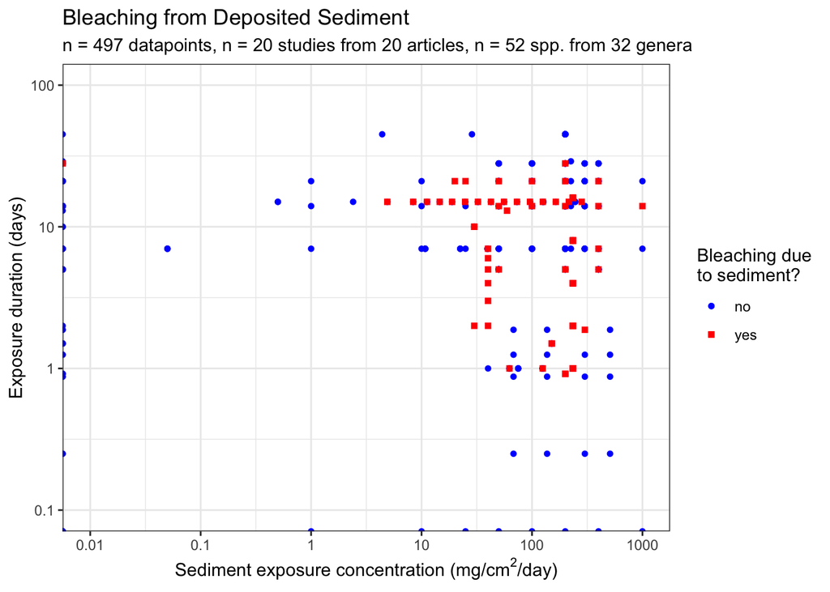

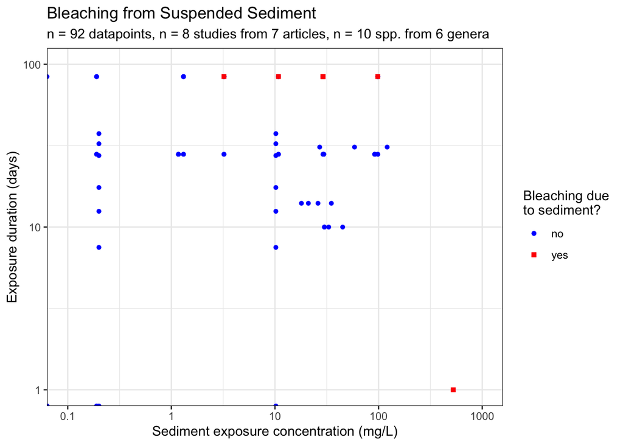

# Threshold Analyses with Binary Data

Now let’s calculate thresholds based on the binary data explored above.

##### DEFINITIONS:

- ‘**LOAEL**’, or the ‘lowest observed adverse effect level’ is defined as the lowest dose at which there was an observed adverse effect.
- ‘**NOAEL**’, or the ‘no observed adverse effect level’ is defined as the highest dose at which there was NOT an observed adverse effect.
- ‘**Adverse effect**’ is defined here as any response of a coral individual, colony, or experimental treatment group that *may* negatively affect the coral’s fitness and/or survival. These adverse effects may include sublethal physiological changes (e.g., significantly reduced growth or photosynthetic rates when compared to coral in ambient/control conditions), bleaching/tissue loss, and mortality. This definition of adverse effect is independent of its magnitude, so while the affect may have potentially reduced fitness, its magnitude may be sufficiently small that the fitness effect is not measureable.

## DEPOSITED SEDIMENT

#### NOAEL/LOAEL defined by exposure concentration

```
##   LOAEL
## 1   4.9
```

```
##   NOAEL
## 1   4.9
```

### NOAEL/LOAEL defined by exposure duration

```
##   LOAEL
## 1 0.917
```

```
##   NOAEL
## 1 0.917
```

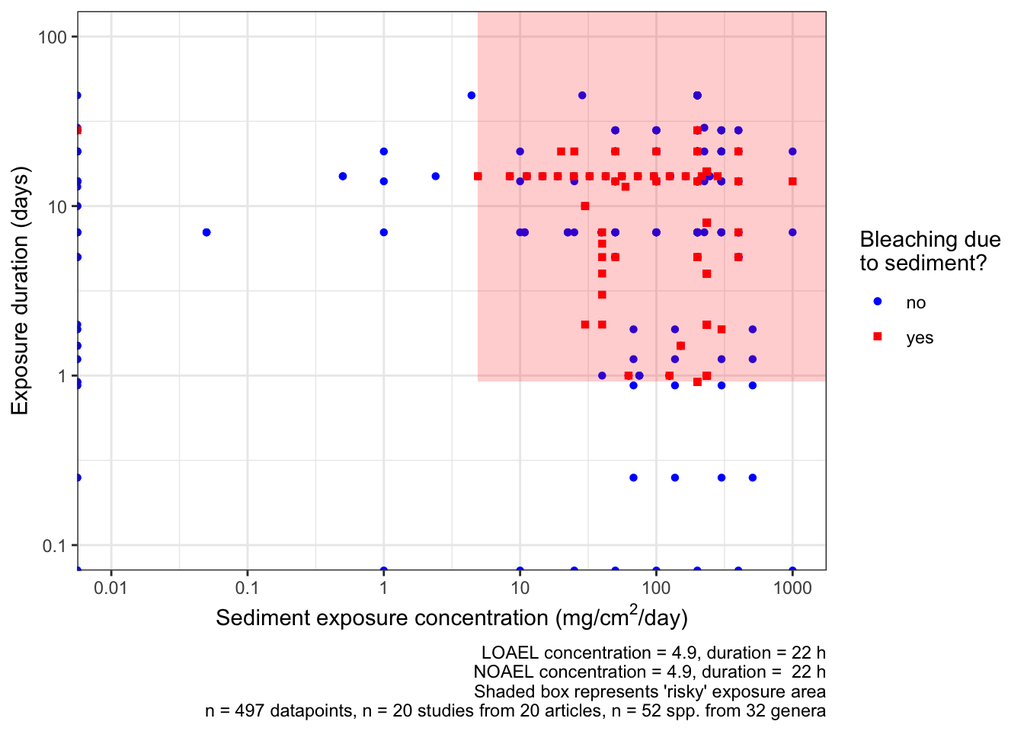

## SUSPENDED SEDIMENT

#### NOAEL/LOAEL defined by exposure concentration

```
##   LOAEL
## 1  3.22
```

```
##   NOAEL
## 1  3.22
```

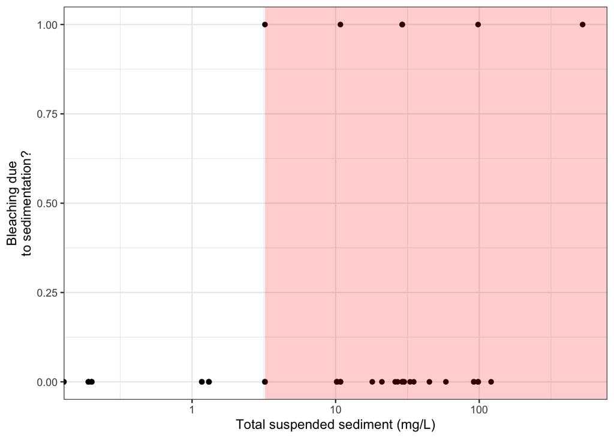

### NOAEL/LOAEL defined by exposure duration

```
##   LOAEL
## 1     1
```

[output not shown]

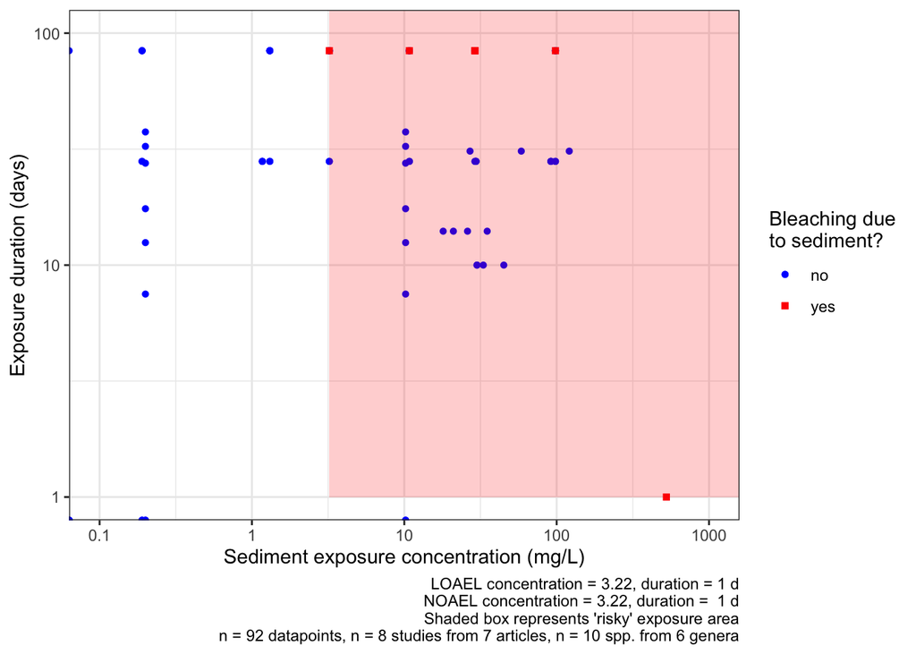

# Logistic Regression Model Fitting

## Deposited Sediment

```
##     n
## 1 352
```

```
## Data: bleachDS2
## Models:
## modDS6: Binary_bleaching_or_reduced_chla ~ Sed_level_stand_mg * Sed_exposure_days +
## modDS6:     (1 | Gsp)
## modDS9: Binary_bleaching_or_reduced_chla ~ Sed_level_stand_mg * Sed_exposure_days +
## modDS9:     (1 | Ref)
## modDS12: Binary_bleaching_or_reduced_chla ~ Sed_level_stand_mg * Sed_exposure_days +
## modDS12:     (1 | Gsp) + (1 | Ref)
##         npar    AIC    BIC   logLik deviance  Chisq Df Pr(>Chisq)
## modDS6     5 230.46 249.78 -110.230   220.46
## modDS9     5 310.85 330.17 -150.427   300.85   0.00  0          1
## modDS12    6 194.08 217.27  -91.042   182.08 118.77  1     <2e-16 ***
## ---
## Signif. codes:  0 '***' 0.001 '**' 0.01 '*' 0.05 '.' 0.1 ' ' 1
```

```
## Data: bleachDS2
## Models:
## modDS10: Binary_bleaching_or_reduced_chla ~ Sed_level_stand_mg + (1 |
## modDS10:     Gsp) + (1 | Ref)
## modDS11: Binary_bleaching_or_reduced_chla ~ Sed_level_stand_mg + Sed_exposure_days +
## modDS11:     (1 | Gsp) + (1 | Ref)
## modDS12: Binary_bleaching_or_reduced_chla ~ Sed_level_stand_mg * Sed_exposure_days +
## modDS12:     (1 | Gsp) + (1 | Ref)
##         npar    AIC    BIC  logLik deviance  Chisq Df Pr(>Chisq)
## modDS10    4 192.99 208.44 -92.494   184.99
## modDS11    5 192.41 211.72 -91.203   182.41 2.5825  1     0.1080
## modDS12    6 194.08 217.26 -91.042   182.08 0.3225  1     0.5701
```

```
## Data: bleachDS2
## Models:
## modDS4: Binary_bleaching_or_reduced_chla ~ Sed_level_stand_mg + (1 |
## modDS4:     Gsp)
## modDS7: Binary_bleaching_or_reduced_chla ~ Sed_level_stand_mg + (1 |
## modDS7:     Ref)
## modDS10: Binary_bleaching_or_reduced_chla ~ Sed_level_stand_mg + (1 |
## modDS10:     Gsp) + (1 | Ref)
##         npar    AIC    BIC   logLik deviance  Chisq Df Pr(>Chisq)
## modDS4     3 229.04 240.63 -111.519   223.04
## modDS7     3 306.91 318.50 -150.454   300.91   0.00  0          1
## modDS10    4 192.99 208.44  -92.494   184.99 115.92  1     <2e-16 ***
## ---
## Signif. codes:  0 '***' 0.001 '**' 0.01 '*' 0.05 '.' 0.1 ' ' 1
```

```
## Generalized linear mixed model fit by maximum likelihood (Laplace
##   Approximation) [glmerMod]
##  Family: binomial  ( logit )
## Formula: Binary_bleaching_or_reduced_chla ~ log10_conc + (1 | Gsp) + (1 |
##     Ref)
##    Data: bleachDS2
##
##      AIC      BIC   logLik deviance df.resid
##    186.1    201.6    -89.1    178.1      348
##
## Scaled residuals:
##     Min      1Q  Median      3Q     Max
## -2.5116 -0.1102 -0.0329  0.1011  3.3666
##
## Random effects:
##  Groups Name        Variance Std.Dev.
##  Gsp    (Intercept) 22.34    4.727
##  Ref    (Intercept) 26.12    5.111
## Number of obs: 352, groups:  Gsp, 35; Ref, 19
##
## Fixed effects:
##             Estimate Std. Error z value Pr(>|z|)
## (Intercept)   -7.939      3.111  -2.552   0.0107 *
## log10_conc     1.300      0.547   2.377   0.0174 *
## ---
## Signif. codes:  0 '***' 0.001 '**' 0.01 '*' 0.05 '.' 0.1 ' ' 1
```

### Effect estimates

```
## [1] 0.9488636
```

```
##
## p     0   1
##   0 255  11
##   1   7  79
```

```
## Area under the curve: 0.9888
```

```
##                      R2m         R2c
## theoretical 7.564074e-03 0.936915395
## delta       1.960027e-05 0.002427765
```

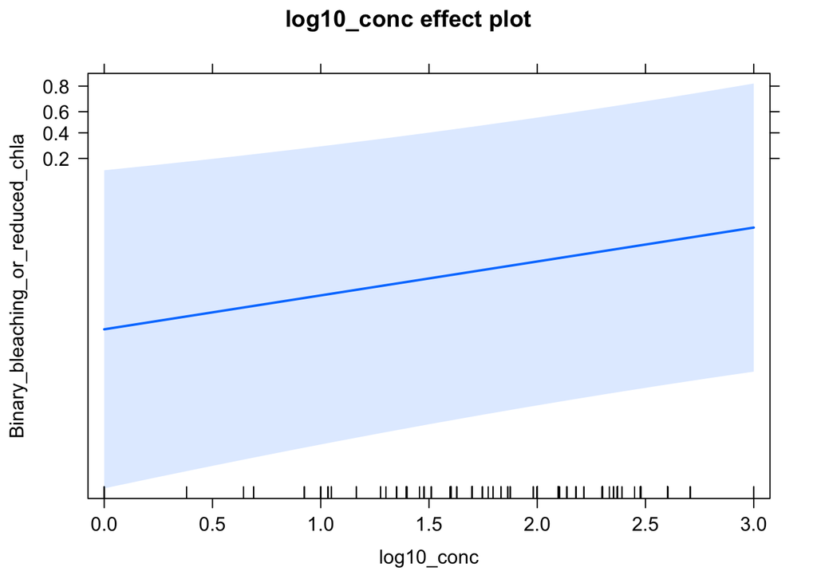

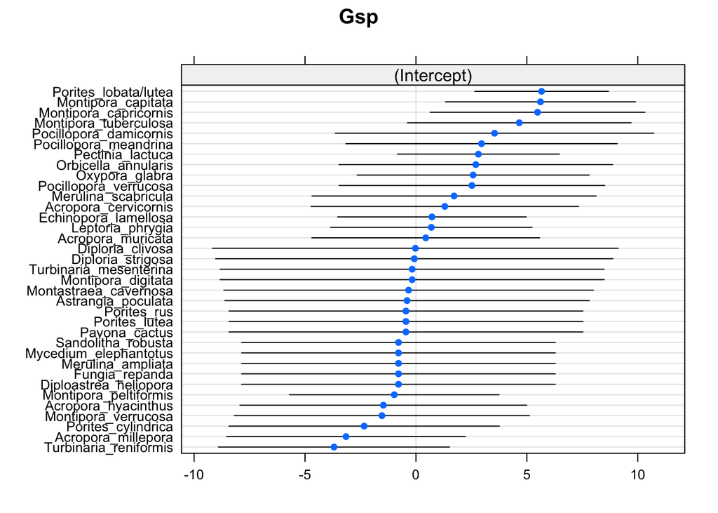

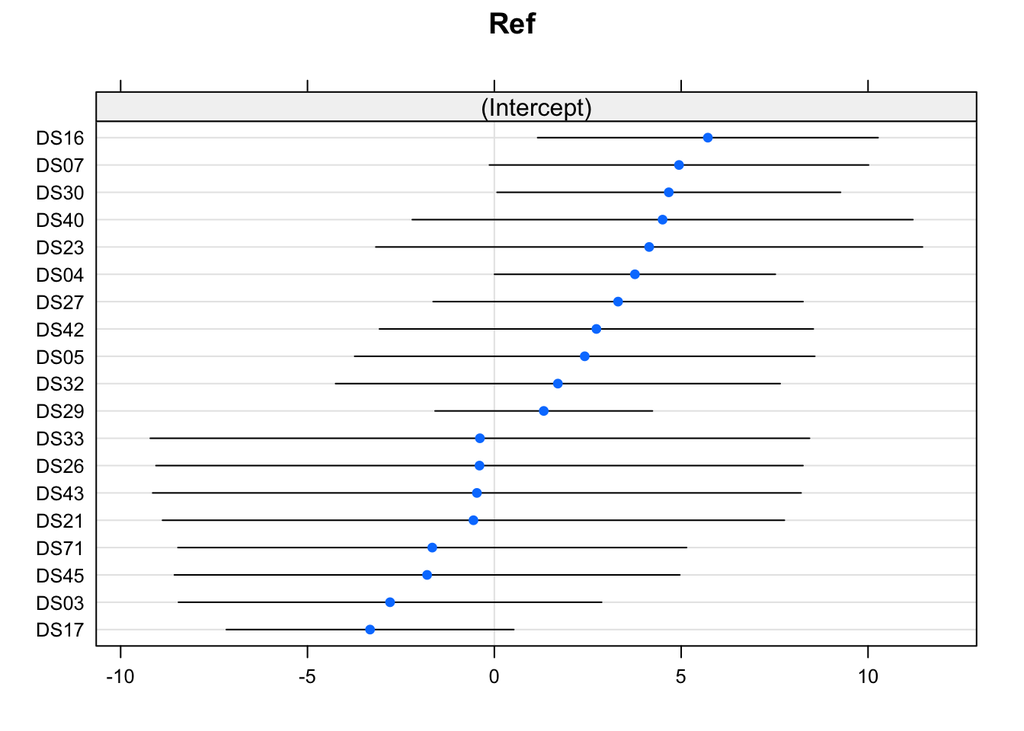

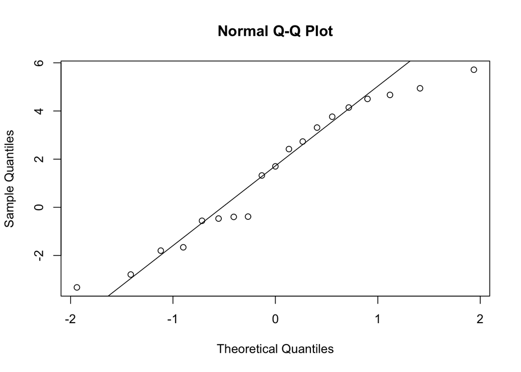

```
##  Groups Name        Std.Dev.
##  Gsp    (Intercept) 4.7268
##  Ref    (Intercept) 5.1110
```

```
## [1] 165.8437
```

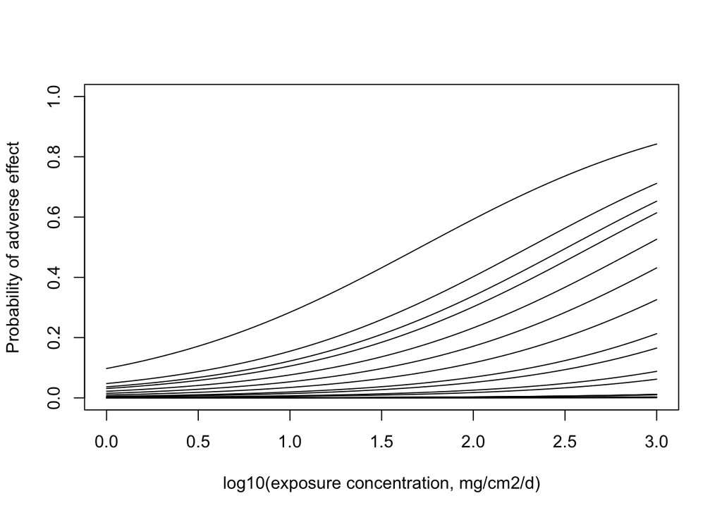

```
##                      Est           LL         UL
## (Intercept) 0.0003565671 8.015217e-07  0.1586234
## log10_conc  3.6704892538 1.256332e+00 10.7236743
```

For every 10-fold increase in sediment exposure, the odds of bleaching increase by 3.7 times (95% CI 1.3, 10.7, GLMM z = 2.376, p = 0.018), after accounting for variation among studies and species.

### Prediction figure

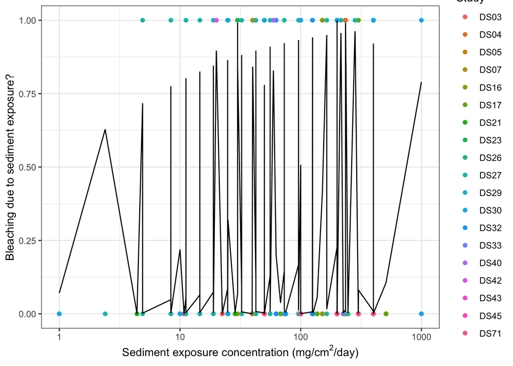

```r
#Overlaying glmm results on figure, but prediction line is jagged...
pred_modDS10_log <- predict(modDS10_log, newdata=bleachDS2, type="response")
bleachDS3 <- cbind(bleachDS2, pred_modDS10_log)

bleachDS_plot <- ggplot(data = bleachDS3) +
    geom_point(mapping = aes(
      x = Sed_level_stand_mg,
      y = Binary_bleaching_or_reduced_chla,
      color = Ref)) +
    labs(x = expression("Sediment exposure concentration (mg/cm"^"2"*"/day)"),
         y = "Bleaching due to sediment exposure?",
         color = "Study") +
    scale_x_log10(limits=c(1,1000),breaks=c(0.01,0.1,1,10,100,1000),
                  label=c("0.01","0.1","1","10","100","1000")) +
    geom_line(aes(x = Sed_level_stand_mg, y = pred_modDS10_log), inherit.aes=FALSE) +
    theme_bw()

bleachDS_plot
```

That plot is confusing to interpret. Let’s see if I can plot the average marginal probability, i.e., the average change in probability of the outcome across the range of the predictor of interest. This is described in some detail at the following, useful website: https://stats.idre.ucla.edu/r/dae/mixed-effects-logistic-regression/

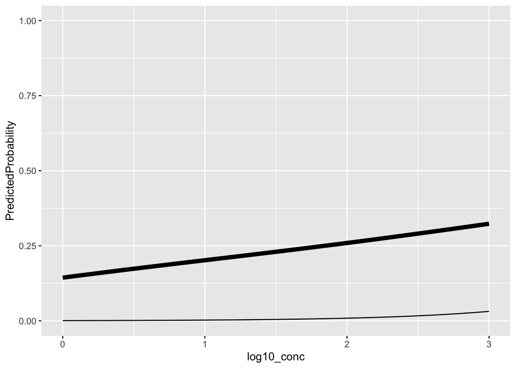

```r
jvalues <- with(bleachDS2, seq(from = min(log10_conc), to = max(log10_conc), length.out = 100))

# calculate predicted probabilities and store in a list
pp <- lapply(jvalues, function(j) {
    bleachDS2$log10_conc <- j
    predict(modDS10_log, newdata = bleachDS2, type = "response")
})

# average marginal predicted probability across a few different sediment levels
#sapply(pp[c(1, 20, 40, 60, 80, 100)], mean)
##
# get the means with lower and upper quartiles
plotdat <- t(sapply(pp, function(x) {
    c(M = mean(x), med = median(x), quantile(x, c(0.25, 0.75)))
}))

# add in log10_conc values and convert to data frame
plotdat <- as.data.frame(cbind(plotdat, jvalues))
plotdat <- plotdat %>% mutate(Sed_level_linear=10^jvalues)

# better names and show the first few rows
colnames(plotdat) <- c("PredictedProbability", "MedianProbability",
                       "LowerQuantile", "UpperQuantile", "log10_conc", "Sed_conc")
#head(plotdat)

# plot average marginal predicted probabilities
ggplot(plotdat, aes(x = log10_conc)) +
  geom_line(aes(y = PredictedProbability), size = 2) +
  geom_line(aes(y = MedianProbability), size = 0.5) +
  ylim(c(0, 1))
```

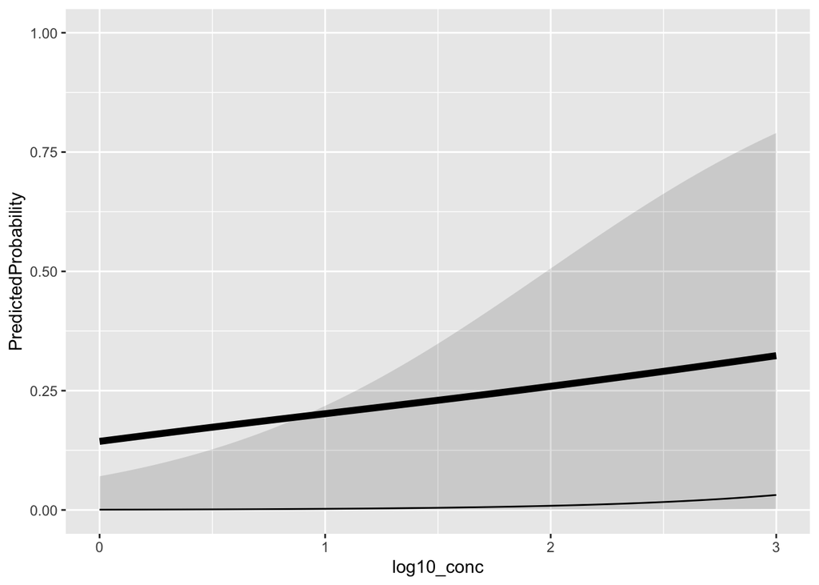

```r
ggplot(plotdat, aes(x = log10_conc)) +
  geom_ribbon(aes(ymin = LowerQuantile, ymax = UpperQuantile), alpha = 0.15) +
  geom_line(aes(y = PredictedProbability), size = 2) +
  geom_line(aes(y = MedianProbability), size = 0.5) +
  ylim(c(0, 1))
```

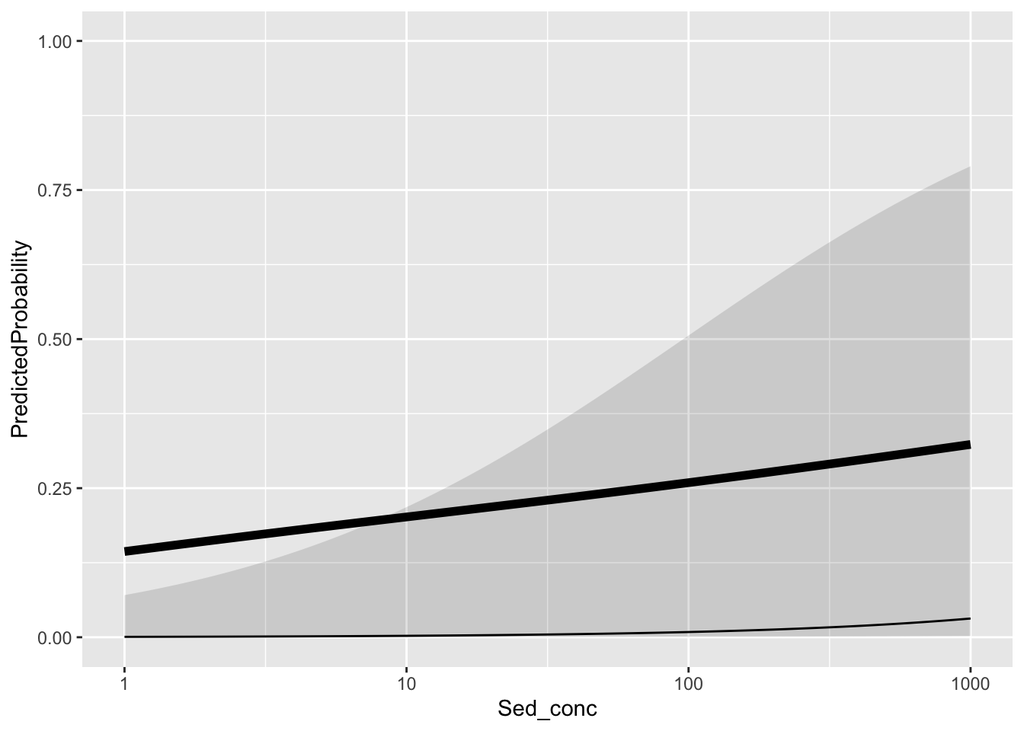

```r
ggplot(plotdat, aes(x = Sed_conc, y = PredictedProbability)) +
  geom_ribbon(aes(ymin = LowerQuantile, ymax = UpperQuantile), alpha = 0.15) +
  geom_line(aes(y = PredictedProbability), size = 2) +
  geom_line(aes(y = MedianProbability), size = 0.5) +
  ylim(c(0, 1)) +
  scale_x_log10()
```

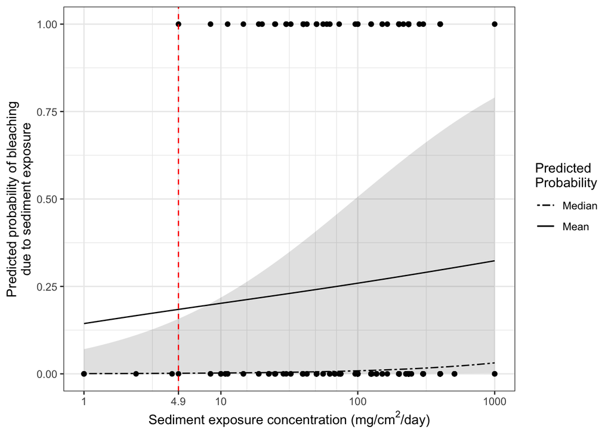

```r
#Overlaying average marginal predicted probabilities on figure
#by Ref
bleachDS_plot2 <- ggplot() +
    geom_point(data = bleachDS2, mapping = aes(
      x = Sed_level_stand_mg,
      y = Binary_bleaching_or_reduced_chla)) +
    labs(x = expression("Sediment exposure concentration (mg/cm"^"2"*"/day)"),
         y = "Predicted probability of bleaching\ndue to sediment exposure",
         linetype = "Predicted\nProbability") +
    scale_x_log10(limits=c(1,1000), breaks=c(0.01,0.1,1,10,100,1000,loael),
                  label=c("0.01","0.1","1","10","100","1000",round(loael,digits=1))) +
    geom_ribbon(data = plotdat, aes(x = Sed_conc, y = PredictedProbability,
                                    ymin = LowerQuantile, ymax = UpperQuantile),
                alpha = 0.15) +
    geom_line(data = plotdat, aes(x = Sed_conc, y = PredictedProbability,
                                  linetype = "twodash")) +
    geom_line(data = plotdat, aes(x = Sed_conc, y = MedianProbability,
                                  linetype = "solid")) +
    geom_vline(xintercept=loael, linetype="dashed", color = "red") +
    theme_bw() +
    scale_linetype_manual(values=c("twodash", "solid"), labels = c("Median","Mean"))# +
#    guides(color = guide_legend(override.aes = list(size = 0.5))) +
#    theme(legend.title = element_text(size = 3),
#          legend.text = element_text(size = 3))

bleachDS_plot2
```

## Suspended Sediment

```
##    n
## 1 54
```

[output not shown]

```
## Data: bleachSS2
## Models:
## modSS15: Binary_bleaching_or_reduced_chla ~ Sed_level_stand_mg * Sed_exposure_days +
## modSS15:     (1 | Ref_name/Ref)
## modSS21: Binary_bleaching_or_reduced_chla ~ Sed_level_stand_mg * Sed_exposure_days +
## modSS21:     (1 | Gsp) + (1 | Ref_name/Ref)
##         npar    AIC    BIC  logLik deviance Chisq Df Pr(>Chisq)
## modSS15    6 36.292 48.226 -12.146   24.292
## modSS21    7 38.292 52.215 -12.146   24.292     0  1     0.9998
```

```
## Data: bleachSS2
## Models:
## modSS5: Binary_bleaching_or_reduced_chla ~ Sed_level_stand_mg + Sed_exposure_days +
## modSS5:     (1 | Gsp)
## modSS8: Binary_bleaching_or_reduced_chla ~ Sed_level_stand_mg + Sed_exposure_days +
## modSS8:     (1 | Ref)
## modSS11: Binary_bleaching_or_reduced_chla ~ Sed_level_stand_mg + Sed_exposure_days +
## modSS11:     (1 | Gsp) + (1 | Ref)
## modSS14: Binary_bleaching_or_reduced_chla ~ Sed_level_stand_mg + Sed_exposure_days +
## modSS14:     (1 | Ref_name/Ref)
## modSS17: Binary_bleaching_or_reduced_chla ~ Sed_level_stand_mg + Sed_exposure_days +
## modSS17:     (1 | Gsp) + (1 | Ref_name)
## modSS20: Binary_bleaching_or_reduced_chla ~ Sed_level_stand_mg + Sed_exposure_days +
## modSS20:     (1 | Gsp) + (1 | Ref_name/Ref)
##         npar  AIC    BIC logLik deviance Chisq Df Pr(>Chisq)
## modSS5     4 34.1 42.056 -13.05     26.1
## modSS8     4 34.1 42.056 -13.05     26.1     0  0     <2e-16 ***
## modSS11    5 36.1 46.045 -13.05     26.1     0  1          1
## modSS14    5 36.1 46.045 -13.05     26.1     0  0          1
## modSS17    5 36.1 46.045 -13.05     26.1     0  0     <2e-16 ***
## modSS20    6 38.1 50.034 -13.05     26.1     0  1          1
## ---
## Signif. codes:  0 '***' 0.001 '**' 0.01 '*' 0.05 '.' 0.1 ' ' 1
```

```
## Data: bleachSS2
## Models:
## modSS8: Binary_bleaching_or_reduced_chla ~ Sed_level_stand_mg + Sed_exposure_days +
## modSS8:     (1 | Ref)
## modSS15: Binary_bleaching_or_reduced_chla ~ Sed_level_stand_mg * Sed_exposure_days +
## modSS15:     (1 | Ref_name/Ref)
##         npar    AIC    BIC  logLik deviance Chisq Df Pr(>Chisq)
## modSS8     4 34.100 42.056 -13.050   26.100
## modSS15    6 36.292 48.226 -12.146   24.292 1.808  2     0.4049
```

```
## Data: bleachSS2
## Models:
## modSS4: Binary_bleaching_or_reduced_chla ~ Sed_level_stand_mg + (1 |
## modSS4:     Gsp)
## modSS7: Binary_bleaching_or_reduced_chla ~ Sed_level_stand_mg + (1 |
## modSS7:     Ref)
## modSS10: Binary_bleaching_or_reduced_chla ~ Sed_level_stand_mg + (1 |
## modSS10:     Gsp) + (1 | Ref)
## modSS13: Binary_bleaching_or_reduced_chla ~ Sed_level_stand_mg + (1 |
## modSS13:     Ref_name/Ref)
## modSS16: Binary_bleaching_or_reduced_chla ~ Sed_level_stand_mg + (1 |
## modSS16:     Gsp) + (1 | Ref_name)
## modSS19: Binary_bleaching_or_reduced_chla ~ Sed_level_stand_mg + (1 |
## modSS19:     Gsp) + (1 | Ref_name/Ref)
##         npar    AIC    BIC  logLik deviance  Chisq Df Pr(>Chisq)
## modSS4     3 44.079 50.046 -19.040   38.079
## modSS7     3 43.212 49.179 -18.606   37.212 0.8668  0     <2e-16 ***
## modSS10    4 45.212 53.168 -18.606   37.212 0.0000  1     0.9996
## modSS13    4 45.107 53.063 -18.554   37.107 0.1049  0     <2e-16 ***
## modSS16    4 45.107 53.063 -18.554   37.107 0.0000  0     1.0000
## modSS19    5 47.107 57.052 -18.554   37.107 0.0000  1     0.9990
## ---
## Signif. codes:  0 '***' 0.001 '**' 0.01 '*' 0.05 '.' 0.1 ' ' 1
```

```
## Data: bleachSS2
## Models:
## modSS7: Binary_bleaching_or_reduced_chla ~ Sed_level_stand_mg + (1 |
## modSS7:     Ref)
## modSS8: Binary_bleaching_or_reduced_chla ~ Sed_level_stand_mg + Sed_exposure_days +
## modSS8:     (1 | Ref)
##        npar    AIC    BIC  logLik deviance  Chisq Df Pr(>Chisq)
## modSS7    3 43.212 49.179 -18.606   37.212
## modSS8    4 34.100 42.056 -13.050   26.100 11.112  1  0.0008576 ***
## ---
## Signif. codes:  0 '***' 0.001 '**' 0.01 '*' 0.05 '.' 0.1 ' ' 1
```

```
## boundary (singular) fit: see ?isSingular
```

```
##
## Call:
## glm(formula = Binary_bleaching_or_reduced_chla ~ Sed_level_stand_mg +
##     Sed_exposure_days, family = binomial(link = "logit"), data = bleachSS2)
##
## Deviance Residuals:
##      Min        1Q    Median        3Q       Max
## -1.30309  -0.56532  -0.11135  -0.06222   1.78862
##
## Coefficients:
##                     Estimate Std. Error z value Pr(>|z|)
## (Intercept)        -7.672614   3.153889  -2.433   0.0150 *
## Sed_level_stand_mg  0.017526   0.007345   2.386   0.0170 *
## Sed_exposure_days   0.074312   0.036248   2.050   0.0404 *
## ---
## Signif. codes:  0 '***' 0.001 '**' 0.01 '*' 0.05 '.' 0.1 ' ' 1
##
## (Dispersion parameter for binomial family taken to be 1)
##
##     Null deviance: 41.654  on 53  degrees of freedom
## Residual deviance: 26.100  on 51  degrees of freedom
## AIC: 32.1
##
## Number of Fisher Scoring iterations: 7
```

### Effect estimates

```
## [1] 0.8518519
```

```
##
## p    0  1
##   0 44  5
##   1  3  2
```

```
## Area under the curve: 0.921
```

```
##                   R2m       R2c
## theoretical 0.6350315 0.6350315
## delta       0.3924085 0.3924085
```

```
##                            Est        2.5 %     97.5 %
## (Intercept)        0.004901321 5.775157e-06 0.08160971
## Sed_level_stand_mg 1.012222478 1.004126e+00 1.02563852
## Sed_exposure_days  1.052858904 1.017483e+00 1.13621778
```

### Prediction figures

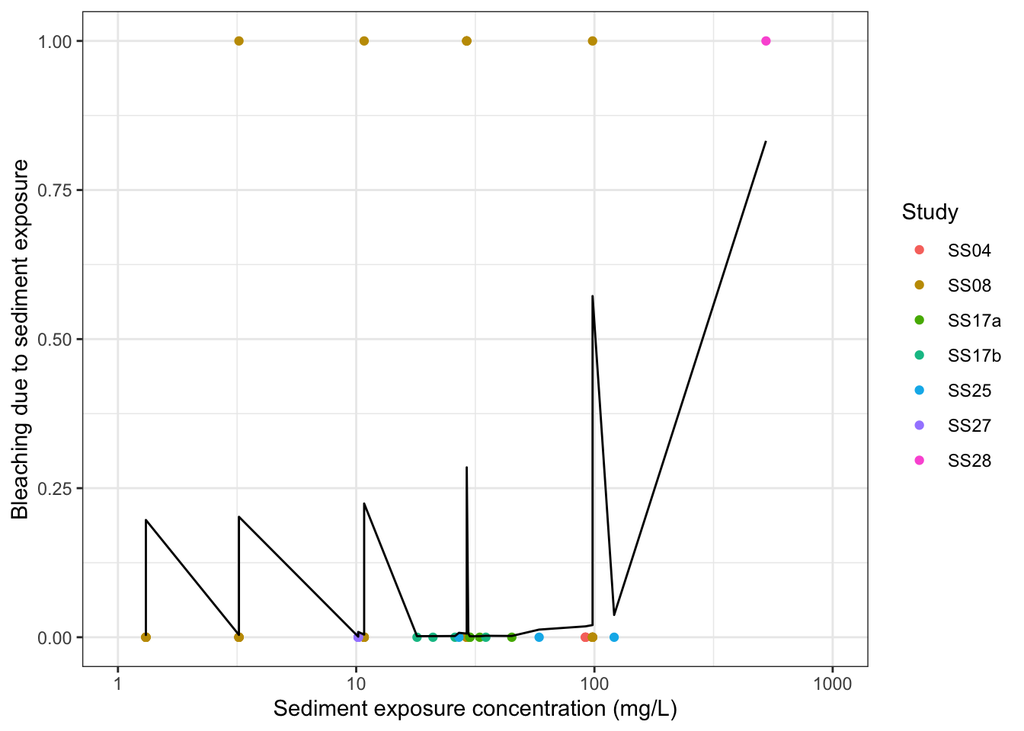

```r
#Overlaying glmm results on figure, but prediction line is jagged...
pred_modSS2 <- predict(modSS2, newdata=bleachSS2, type="response")
bleachSS3 <- cbind(bleachSS2, pred_modSS2)

bleachSS_plot <- ggplot(data = bleachSS3) +
    geom_point(mapping = aes(
      x = Sed_level_stand_mg,
      y = Binary_bleaching_or_reduced_chla,
      color = Ref)) +
    labs(x = "Sediment exposure concentration (mg/L)",
         y = "Bleaching due to sediment exposure",
         color = "Study") +
    scale_x_log10(limits=c(1,1000),breaks=c(0.01,0.1,1,10,100,1000),
                  label=c("0.01","0.1","1","10","100","1000")) +
    geom_line(aes(x = Sed_level_stand_mg, y = pred_modSS2), inherit.aes=FALSE) +
    theme_bw()

bleachSS_plot
```

That plot is confusing to interpret. Let’s see if I can plot the average marginal probability, i.e., the average change in probability of the outcome across the range of the predictor of interest. This is described in some detail at the following, useful website: https://stats.idre.ucla.edu/r/dae/mixed-effects-logistic-regression/

#### By sediment exposure concentration

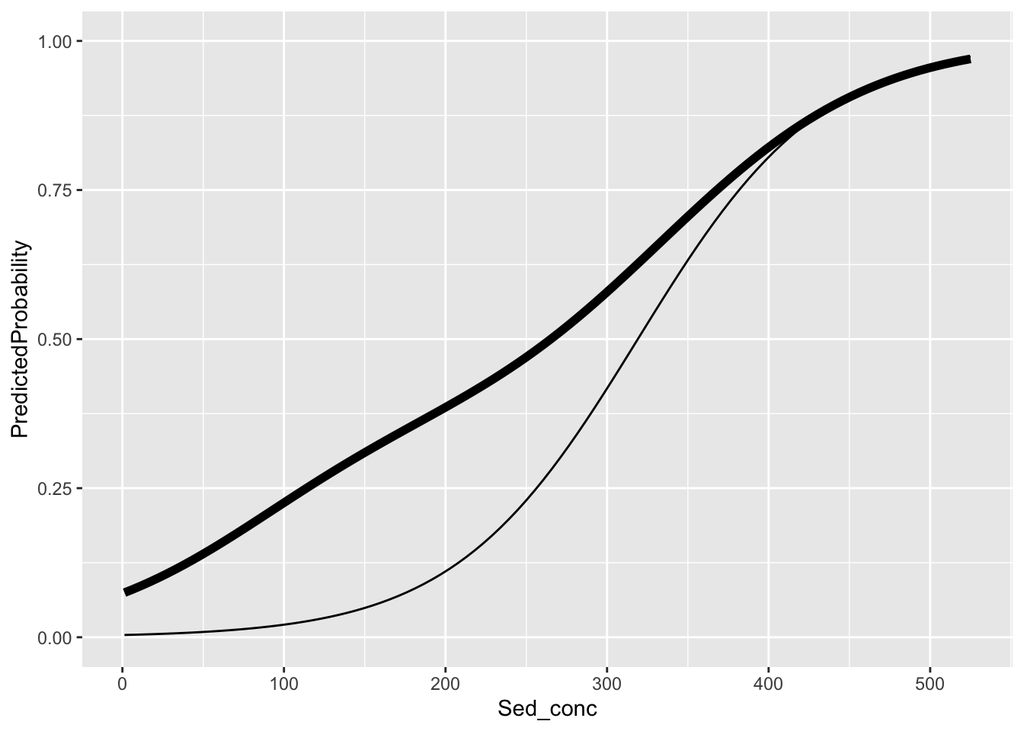

```r
jvalues <- with(bleachSS2, seq(from = min(Sed_level_stand_mg), to = max(Sed_level_stand_mg), length.out = 100))

# calculate predicted probabilities and store in a list
pp <- lapply(jvalues, function(j) {
    bleachSS2$Sed_level_stand_mg <- j
    predict(modSS2, newdata = bleachSS2, type = "response")
})

# average marginal predicted probability across a few different sediment levels
#sapply(pp[c(1, 20, 40, 60, 80, 100)], mean)
## [1] 0.1797186 0.1960244 0.2142042 0.2333993 0.2535694 0.2746604
# get the means with lower and upper quartiles
plotdat <- t(sapply(pp, function(x) {
    c(M = mean(x), med = median(x), quantile(x, c(0.25, 0.75)))
}))

# add in Sed_level_stand_mg values and convert to data frame
plotdat <- as.data.frame(cbind(plotdat, jvalues))

# better names and show the first few rows
colnames(plotdat) <- c("PredictedProbability", "MedianProbability",
                       "LowerQuantile", "UpperQuantile", "Sed_conc")
#head(plotdat)

# plot average marginal predicted probabilities
ggplot(plotdat, aes(x = Sed_conc)) +
  geom_line(aes(y = PredictedProbability), size = 2) +
  geom_line(aes(y = MedianProbability), size = 0.5) +
  ylim(c(0, 1))
```

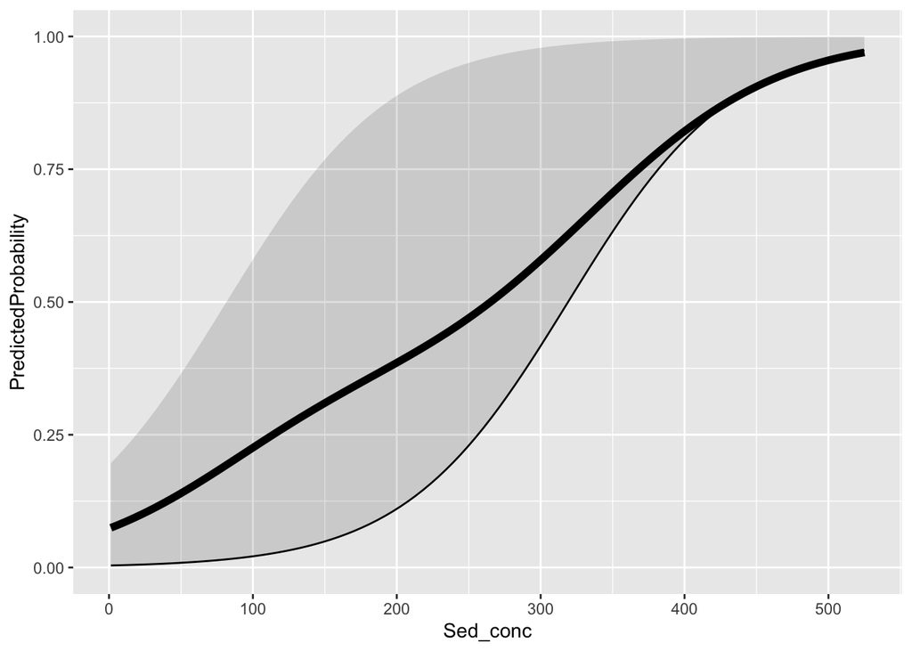

```r
ggplot(plotdat, aes(x = Sed_conc)) +
  geom_ribbon(aes(ymin = LowerQuantile, ymax = UpperQuantile), alpha = 0.15) +
  geom_line(aes(y = PredictedProbability), size = 2) +
  geom_line(aes(y = MedianProbability), size = 0.5) +
  ylim(c(0, 1))
```

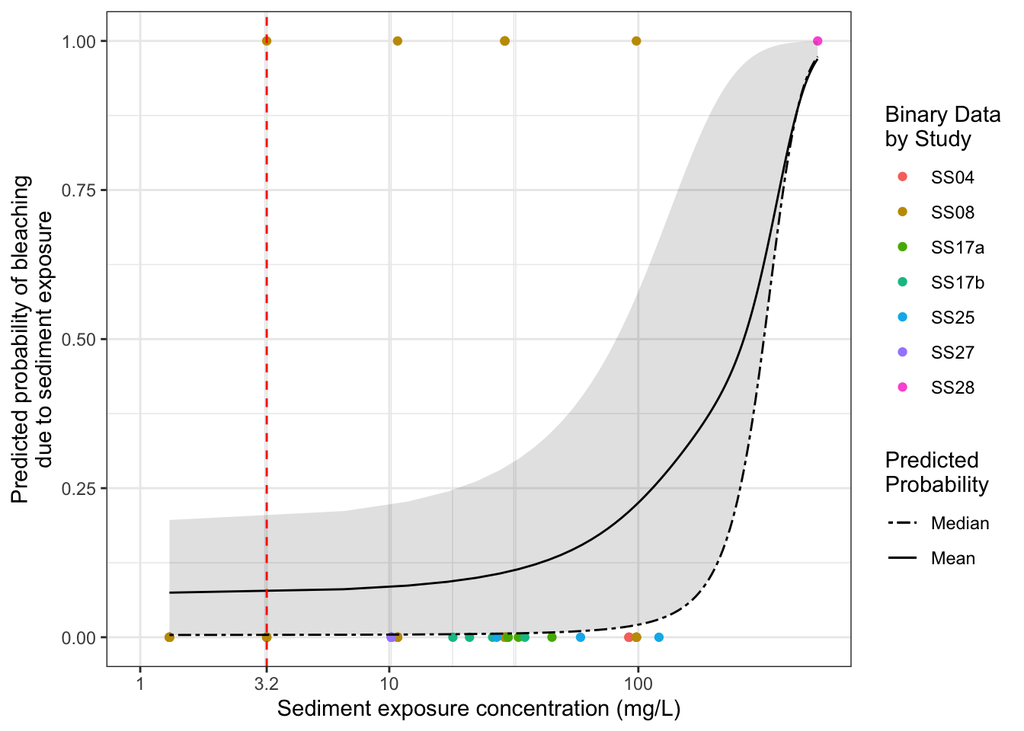

```r
#Overlaying average marginal predicted probabilities on figure
#by Ref
bleachSS_plot2 <- ggplot() +
    geom_point(data = bleachSS2, mapping = aes(
      x = Sed_level_stand_mg,
      y = Binary_bleaching_or_reduced_chla,
      color = Ref)) +
    labs(x = "Sediment exposure concentration (mg/L)",
         y = "Predicted probability of bleaching\ndue to sediment exposure",
         color = "Binary Data\nby Study",
         linetype = "Predicted\nProbability") +
    scale_x_log10(limits=c(1,max(bleachSS2$Sed_level_stand_mg)),
                  breaks=c(0.01,0.1,1,10,100,1000,loaelSS),
                  label=c("0.01","0.1","1","10","100","1000",round(loaelSS,digits=1))) +
    geom_ribbon(data = plotdat, aes(x = Sed_conc, y = PredictedProbability,
                                    ymin = LowerQuantile, ymax = UpperQuantile),
                alpha = 0.15) +
    geom_line(data = plotdat, aes(x = Sed_conc, y = PredictedProbability,
                                  linetype = "twodash")) +
    geom_line(data = plotdat, aes(x = Sed_conc, y = MedianProbability,
                                  linetype = "solid")) +
    geom_vline(xintercept=loaelSS, linetype="dashed", color = "red") +
    theme_bw() +
    scale_linetype_manual(values=c("twodash", "solid"), labels = c("Median","Mean"))

bleachSS_plot2
```

#### By sediment exposure duration

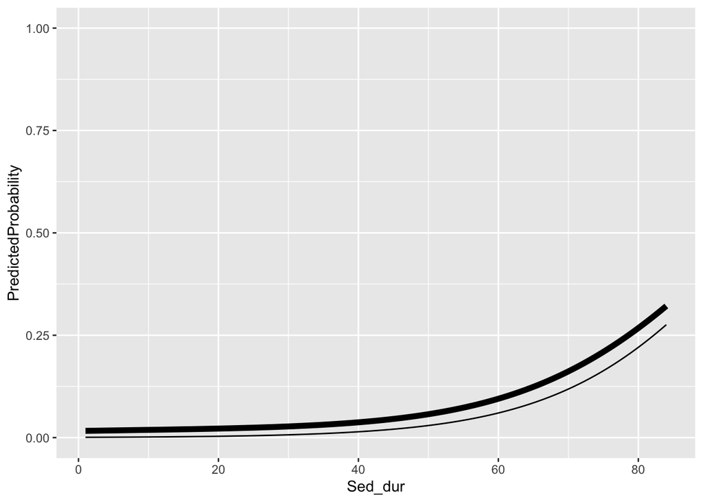

```r
jvalues <- with(bleachSS2, seq(from = min(Sed_exposure_days), to = max(Sed_exposure_days), length.out = 100))

# calculate predicted probabilities and store in a list
pp <- lapply(jvalues, function(j) {
    bleachSS2$Sed_exposure_days <- j
    predict(modSS2, newdata = bleachSS2, type = "response")
})

# average marginal predicted probability across a few different sediment levels
#sapply(pp[c(1, 20, 40, 60, 80, 100)], mean)
## [1] 0.1797186 0.1960244 0.2142042 0.2333993 0.2535694 0.2746604
# get the means with lower and upper quartiles
plotdat <- t(sapply(pp, function(x) {
    c(M = mean(x), med = median(x), quantile(x, c(0.25, 0.75)))
}))

# add in Sed_exposure_days values and convert to data frame
plotdat <- as.data.frame(cbind(plotdat, jvalues))

# better names and show the first few rows
colnames(plotdat) <- c("PredictedProbability", "MedianProbability",
                       "LowerQuantile", "UpperQuantile", "Sed_dur")
#head(plotdat)

# plot average marginal predicted probabilities
ggplot(plotdat, aes(x = Sed_dur)) +
  geom_line(aes(y = PredictedProbability), size = 2) +
  geom_line(aes(y = MedianProbability), size = 0.5) +
  ylim(c(0, 1))
```

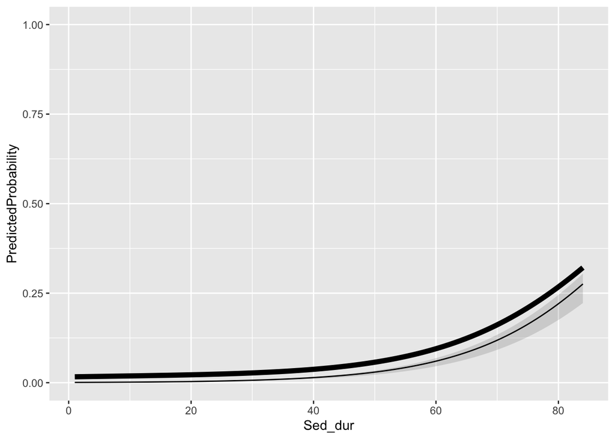

```r
ggplot(plotdat, aes(x = Sed_dur)) +
  geom_ribbon(aes(ymin = LowerQuantile, ymax = UpperQuantile), alpha = 0.15) +
  geom_line(aes(y = PredictedProbability), size = 2) +
  geom_line(aes(y = MedianProbability), size = 0.5) +
  ylim(c(0, 1))
```

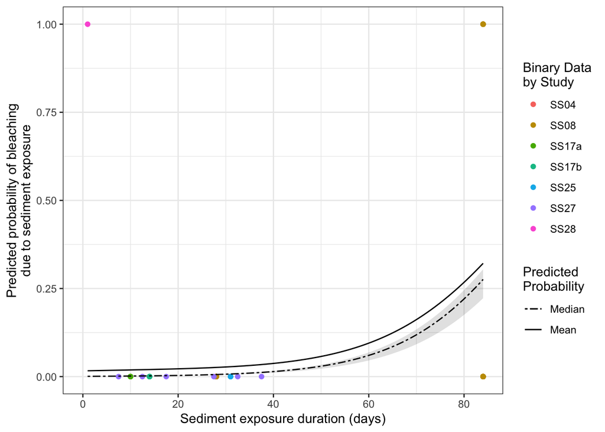

```r
#Overlaying average marginal predicted probabilities on figure
#by Ref
bleachSS_plot3 <- ggplot() +
    geom_point(data = bleachSS2, mapping = aes(
      x = Sed_exposure_days,
      y = Binary_bleaching_or_reduced_chla,
      color = Ref)) +
    labs(x = "Sediment exposure duration (days)",
         y = "Predicted probability of bleaching\ndue to sediment exposure",
         color = "Binary Data\nby Study",
         linetype = "Predicted\nProbability") +
    scale_x_continuous(limits=c(0,max(bleachSS2$Sed_exposure_days))) +
    geom_ribbon(data = plotdat, aes(x = Sed_dur, y = PredictedProbability,
                                    ymin = LowerQuantile, ymax = UpperQuantile),
                alpha = 0.15) +
    geom_line(data = plotdat, aes(x = Sed_dur, y = PredictedProbability,
                                  linetype = "twodash")) +
    geom_line(data = plotdat, aes(x = Sed_dur, y = MedianProbability,
                                  linetype = "solid")) +
    theme_bw() +
    scale_linetype_manual(values=c("twodash", "solid"), labels = c("Median","Mean"))

bleachSS_plot3
```